# Data606Homework4

Stephanie Roark

10/21/2018

## Chapter 4 Foundations for Inference

### 4.4 Heights of adults. Researchers studying anthropometry collected body girth measurements and skeletal diameter measurements, as well as age, weight, height and gender, for 507 physicallyactive individuals. The histogram below shows the sample distribution of heights in centimeters.

Min 147.2 Q1 163.8 Median 170.3 Mean 171.1 SD 9.4 Q3 177.8 Max 198.1

1. What is the point estimate for the average height of active individuals? What about the median?

The average height is 171.1 while the median is 170.3.

2. What is the point estimate for the standard deviation of the heights of active individuals? What about the IQR?

The standard deviation is 9.4 and the IQR is Q3-Q1 =

```r
177.8-163.8
```

```
## [1] 14
```

3. Is a person who is 1m 80cm (180 cm) tall considered unusually tall? And is a person who is 1m 55cm (155cm) considered unusually short? Explain your reasoning.

180cm falls approximately 1 standard deviation above the mean so not unusually tall but taller than average. 155cm is about 1.5 standard deviations from the mean so they are much shorter than average.

4. The researchers take another random sample of physically active individuals. Would you expect the mean and the standard deviation of this new sample to be the ones given above? Explain your reasoning.

They will likely be similar but not exact because the new sample will pull different data.

5. The sample means obtained are point estimates for the mean height of all active individuals, if the sample of individuals is equivalent to a simple random sample. What measure do we use to quantify the variability of such an estimate? Compute this quantity using the data from the original sample under the condition that the data are a simple random sample.

The standard error gives us the variability in the estimates.

$SE=σ/√N$ =

```r
9.4/(507)^.5
```

```
## [1] 0.4174687
```

### 4.14 Thanksgiving spending, Part I. The 2009 holiday retail season, which kicked off on November 27, 2009 (the day after Thanksgiving), had been marked by somewhat lower self-reported consumer spending than was seen during the comparable period in 2008. To get an estimate of consumer spending, 436 randomly sampled American adults were surveyed. Daily consumer spending for the six-day period after Thanksgiving, spanning the Black Friday weekend and Cyber Monday, averaged $84.71. A 95% confidence interval based on this sample is ($80.31, $89.11).

Determine whether the following statements are true or false, and explain your reasoning.

1. We are 95% confident that the average spending of these 436 American adults is between $80.31 and $89.11.

This is false because the quesiton is based on the sample mean of only 436 AMericans and not the actual average population.

2. This confidence interval is not valid since the distribution of spending in the sample is right skewed.

This is false since there are more than 30 independent or random samples and the skew is not a signigicant factor.

3. 95% of random samples have a sample mean between $80.31 and $89.11.

This is false as the confidence interval is telling us about the probability that the true population mean is contained the interval, not the sample mean.

4. We are 95% confident that the average spending of all American adults is between $80.31 and $89.11.

This is true as the population mean or average spending should fall within the confidence interval.

5. A 90% confidence interval would be narrower than the 95% confidence interval since we don’t need to be as sure about our estimate.

This is true as the 90% confidence interval is more narrow as it does not cover as many values and we do not need to be as confident of our estimates.

6. In order to decrease the margin of error of a 95% confidence interval to a third of what it is now, we would need to use a sample 3 times larger.

This is false as we would need to increase the sample size by N^2 because our error equation is σ/√N. so we would have to increase it by 3^2 or 9 to get a 1/3 decrease in our margin of error.

7. The margin of error is 4.4.

```r
(89.11-80.31)/2
```

```
## [1] 4.4
```

### 4.24 Gifted children, Part I. Researchers investigating characteristics of gifted children collected data from schools in a large city on a random sample of thirty-six children who were identified as gifted children soon after they reached the age of four. The following histogram shows the distribution of the ages (in months) at which these children first counted to 10 successfully. Also provided are some sample statistics.

Age child first counted to 10 (in months) n 36 min 21 mean 30.69 sd 4.31 max 39

1. Are conditions for inference satisfied?

The determining factors for inference are if a sample consists of at least 30 independent observations and the data are not strongly skewed. The conditions are met for inference as the sample is random and greater than 30 as well as not strongly skewed.

2. Suppose you read online that children first count to 10 successfully when they are 32 months old, on average. Perform a hypothesis test to evaluate if these data provide convincing evidence that the average age at which gifted children fist count to 10 successfully is less than the general average of 32 months. Use a significance level of 0.10.

H0: μ = 32 months, H1: μ < or > 32 months α = 0.1

$SE=σ/√N$ =

```r
4.31/36^.5
```

```
## [1] 0.7183333
```

Z = (x¯-null value)/(SE)x¯ +

```r
(30.69-32)/0.718
```

```
## [1] -1.824513
```

P = 0.034

3. Interpret the p-value in context of the hypothesis test and the data.

4. Calculate a 90% confidence interval for the average age at which gifted children first count to 10 successfully.

x¯ ± z*SE =

```r
30.69 - 1.65*0.718
```

```
## [1] 29.5053
```

```r
30.69 + 1.65*0.718
```

```
## [1] 31.8747
```

5. Do your results from the hypothesis test and the confidence interval agree? Explain.

The confidence interval does not include the null mean of 32. The P value is much lower than 0.1. Therefore we reject the null hypothesis.

### 4.26 Gifted children, Part II. Exercise 4.24 describes a study on gifted children. In this study, along with variables on the children, the researchers also collected data on the mother’s and father’s IQ of the 36 randomly sampled gifted children. The histogram below shows the distribution of mother’s IQ. Also provided are some sample statistics.

Mother’s IQ n 36 min 101 mean 118.2 sd 6.5 max 131

1. Perform a hypothesis test to evaluate if these data provide convincing evidence that the average IQ of mothers of gifted children is diffrent than the average IQ for the population at large, which is 100. Use a significance level of 0.10.

H0: μ = 100; H1: μ < or > 100 α = 0.1

$SE=σ/√N$ =

```r
6.5/36^.5
```

```
## [1] 1.083333
```

Z = (x¯-null value)/(SE)x¯ +

```r
(118.2-100)/1.083
```

```
## [1] 16.80517
```

P = 0 approximately.

2. Calculate a 90% confidence interval for the average IQ of mothers of gifted children.

x¯ ± z*SE =

```r
118.2 - 1.65*1.083
```

```
## [1] 116.413
```

```r
118.2 + 1.65*1.083
```

```
## [1] 119.987
```

3. Do your results from the hypothesis test and the confidence interval agree? Explain.

Yes, the confidence interval does not contain the null mean and the P score is basically 0. We reject the null hypothesis that the average IQ of mothers of gifted children is average IQ of the population at large.

### 4.34 CLT. Define the term “sampling distribution” of the mean, and describe how the shape, center, and spread of the sampling distribution of the mean change as sample size increases.

The sampling distribution of the mean is a distribution of the values that the mean of a sample takes on in all of the possible samples of a specific size that can be made from a given population.

The Central Limit Theorem states that when the sample size is small, the normal approximation may not be very good. However, as the sample size becomes large, the normal approximation improves.

With small samples the shape might be skewed and the spread larger than a normal distribution’s spread. As the sample size increases, the shape grows closer to the normal distribution centering around 0 and the spread will pull in closer as there is less variability in the sample means.

### 4.40 CFLBs. A manufacturer of compact fluorescent light bulbs advertises that the distribution of the lifespans of these light bulbs is nearly normal with a mean of 9,000 hours and a standard deviation of 1,000 hours.

1. What is the probability that a randomly chosen light bulb lasts more than 10,500 hours?

```r
1-pnorm(q=10500, mean=9000, sd=1000)
```

```
## [1] 0.0668072
```

2. Describe the distribution of the mean lifespan of 15 light bulbs.

```r
sd <- 1000
mean <- 9000
se <- sd/sqrt(15)
se
```

```
## [1] 258.1989
```

```r
10500 - 1.65*se
```

```
## [1] 10073.97
```

```r
10500 + 1.65*se
```

```
## [1] 10926.03
```

3. What is the probability that the mean lifespan of 15 randomly chosen light bulbs is more than 10,500 hours?

Z = (10500−9000)/258.19 = 5.81

```r
1-pnorm(q=10500, mean=9000, sd=258)
```

```
## [1] 3.050719e-09
```

The probability that the mean lifespan is more than 10,500 is almost 0.

4. Sketch the two distributions (population and sampling) on the same scale.

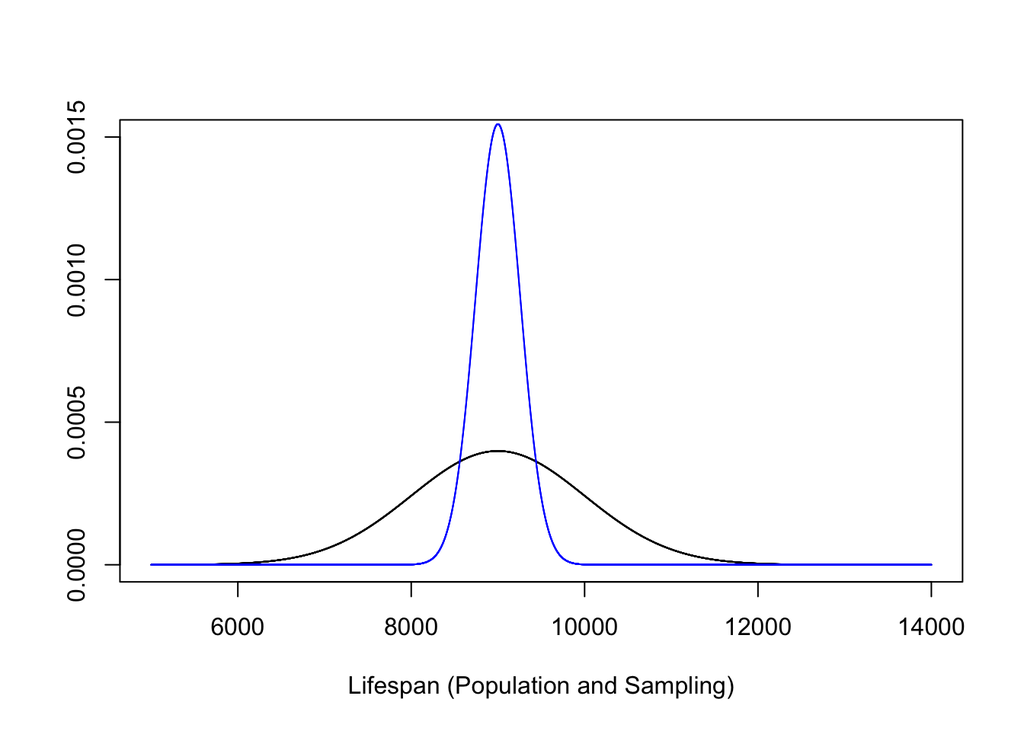

```r
scale <- seq(5000,14000,0.01)
plot(scale, dnorm(scale,9000, 1000), type="l", ylim = c(0,0.0015), ylab = "", xlab = "Lifespan (Population and Sampling)")
lines(scale, dnorm(scale,9000, 258.1989), col="blue")
```

5. Could you estimate the probabilities from parts (a) and (c) if the lifespans of light bulbs had a skewed distribution?

Not if the distribution was greatly skewed as then it can not be approximated with the normal distribution, however if the sampling distribution can be understood there are other methods that can be used to get estimates for skewed distributions.

### 4.48 Same observation, different sample size. Suppose you conduct a hypothesis test based on a sample where the sample size is n = 50, and arrive at a p-value of 0.08. You then refer back to your notes and discover that you made a careless mistake, the sample size should have been n = 500. Will your p-value increase, decrease, or stay the same? Explain.

The p-value can be computed by using the Z-score of the point estimate and the normal probability table.

Z = (point estimate - null value)/SEpoint estimate

SE = σ/√N

Raising N will increase the Z score which is used to calculate the P value. For a left tail, increasing N would cause z score to increase the p-value to decrease. For a right tail, the effect of increasing N is to increase Z would make the p-value would increase.